# Australia on Fire

Kayleigh Wilson

2020-01-13

## Goals

The goal of this report is to demonstrate the use of the **AirSensor** package to create a local archive or PurpleAir data covering the December 2019 - January 2020 fires and smoke in Australia.

We begin by loading the necessary packages:

```r
library(dplyr)            # data manipulation
library(ggplot2)          # plotting
library(PWFSLSmoke)       # USFS monitor data access and plotting
library(AirSensor)        # PurpleAir sensor data access and plotting
library(AirMonitorPlots)  # Advanced plots for monitors
```

Within the AirSensor package, data can come from two different sources, we consider a ‘monitor’ to be something installed and operated federally, in contrast to a ‘sensor’ which is a PurpleAir sensor, installed and operated by anyone. However, data collected by a PurpleAir sensor can be changed into a data format recognized by some of the plotting functions designed for the ‘monitor’ data. An example of how to do this is outlined in this report, but first, lets get the data.

## Getting the Data

### Set up a local archive

First, if the archive base directory does not exist, we can set it up so that RStudio knows where to find and write data.

```r
archiveBaseDir <- path.expand("~/Data/Australia_on_fire")
if ( !dir.exists(archiveBaseDir) ) {
  dir.create(archiveBaseDir)
}

setArchiveBaseDir(archiveBaseDir)
```

### Load synoptic data for Australia

Next, make sure the Australia ‘pas’ exists in your directory. The following chunk of code will check to to see if it exists, if not, it will download it.

```r
filePath_pas <- file.path(archiveBaseDir, "pas_au.rda")

if ( !file.exists(filePath_pas) ) {
  initializeMazamaSpatialUtils()
  pas_au <- pas_createNew(countryCodes = "AU", includePWFSL = TRUE)
  save(pas_au, file = filePath_pas)
}

pas <- get(load(filePath_pas))
```

### View the ‘pas’ data

A ‘pas’ (PurpleAir synoptic) object is a dataframe that contains metadata and PM 2.5 averages for many purple air sensors in a designated region. Each pas object can be filtered and edited to contain whichever arrangement of sensors that the programmer desires based on location, state, name, etc. Data averages that the pas object contain are current at the time that the pas is created and are different from time series data which are reserved for the ‘pat’ objects.

We can view the locations of each sensor and the AQI (Air Quality Index) over the last hour using the pas_leaflet function.

```r
pas_leaflet(pas)
```

[interactive chart not shown]

### Load time series data for Australia

It looks like the air quality in Sydney is currently unhealthy, let’s look at data from a sensor in the Sydney area. The following chunk will check to see if the ‘pat’ or PurpleAir time sereies, is located in the local directory, if it’s not, it will be downloaded.

```r
label <- c("Jannali" )

filePath_jannali <- file.path(archiveBaseDir, "pat_jannali.rda")

if ( file.exists(filePath_jannali) ) {
  pat_jannali <- get(load(filePath_jannali))
} else {
  pat_jannali <- pat_createNew(pas = pas,
                               label = label,
                               startdate = 20191229,
                               enddate = 20200110)
  save(pat_jannali, file = filePath_jannali)
}
```

### View the ‘pat’ data

A ‘pat’ (PurpleAir time series) object is a list of two dataframes, one metadata dataframe, and one time series dataframe for one sinlge PurpleAir sensor. Each ‘pat’ contains a time series for a temperature channel, a humidity channel and two PM 2.5 channel’s; A and B.

The following chunk demonstrates a simple way to have a quick look at the data contained in a ‘pat’ object. The plot shows both A and B channels as well as temperature and humidity. The plotting function is flexible and has options for choosing which channels to display, on the same or individual axes.

In this case we see that the data look good, channels A and B are both showing lots of PM 2.5 at the “Jannali” sensor location off and on thorughout the last few weeks.

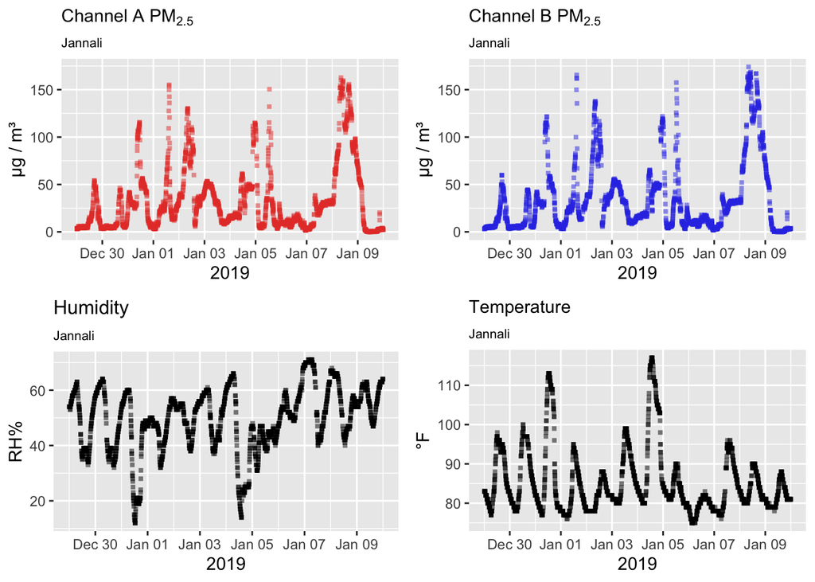

```r
pat_multiplot(pat_jannali)
```

## Explore the ‘pas’ dataframe

For the purposes of this exploratory example, we are focusing on Australia but maybe we want to filter even more and just look at the sensors within a certain radius of the one we chose in Sydney.

```r
lon <- pat_jannali$meta$longitude
lat <- pat_jannali$meta$latitude

pas_sydney <-
  pas_au %>%
  pas_filterNear(longitude = lon, latitude = lat, radius = "50 km")

pas_leaflet(pas_sydney)
```

[interactive chart not shown]

### Filter the ‘pas’ based on conditions

The air quality in Sydney appears to be unhealthy, but let’s look for the sensors that are reporting the highest AQI levels. This chunk of code filters the ‘pas’ for the sensors that have an AQI value higher than 150 which corresponds to levels of concern called “Very Unhealthy”, or “Hazardous” when the AQI value is higher than 250.

It is important to note here that the sensors listed in the ‘pas’ after filtering will depend on the date that the original ‘pas’ was generated. Since data averages are generated each time a ‘pas’ is created, the ‘pas’ that you use may show different AQI averages for the same sensors than the ‘pas’ that we are using here. For the purposes of this example, I generated this ‘pas’ on January 10, 2020.

```r
pas_v_unhealthy <-
  pas_au%>%
  pas_filter(pm25_1hr > 150)

pas_leaflet(pas_v_unhealthy)
```

[interactive chart not shown]

## Explore the ‘pat’ data

### Download ‘pat’ data based on the bad air quality

Now that the ‘pas’ has been filtered based on the worst air quality, we can download the ‘pat’ objets for sensors listed in the ‘pas’. Here, you could download all the sensors in the newly filtered ‘pas’ but in this example for the purposes of reproducibility, I am going to continue to use the `pas_au` object as the reference ‘pas’ to ensure that the sensors I am referencing are present in any ‘pas’ that one may download in the future. This is once again, due to ephemeral nature of the AQI data averages which are generated at the time of the ‘pas’ creation.

Since the fires in Australia started, new PurpleAir sensors have been popping up left and right. Let’s start by grabbing data from sensors with the longest history. The following chunk will check to see if the ‘pat’ objects are already in the local data directory, if not, they will be downloaded.

```r
filePath_chisholm <- file.path(archiveBaseDir, "pat_chisholm.rda")
if ( file.exists(filePath_chisholm) ) {
  pat_chisholm <- get(load(filePath_chisholm))
}

filePath_moruya <- file.path(archiveBaseDir, "pat_moruya.rda")
if ( file.exists(filePath_moruya) ) {
  pat_moruya <- get(load(filePath_moruya))
}

filePath_windang <- file.path(archiveBaseDir, "pat_windang.rda")
if ( file.exists(filePath_windang) ) {
  pat_windang <- get(load(filePath_windang))
} else {

  unhealthy_labels <- c("Chisholm ACT Australia",
                        "MORUYA HEADS",
                        "Windang, Ocean Street")

  patList <- list()
  for ( label in unhealthy_labels ) {
    patList[[label]] <- pat_createNew(label = label,
                                      pas = pas_au,
                                      startdate = 20191210,
                                      enddate = 20200110)
  }

  pat_chisholm <- patList[[1]]
  save(pat_chisholm, file = filePath_chisholm)

  pat_moruya <- patList[[2]]
  save(pat_moruya, file = filePath_moruya)

  pat_windang <- patList[[3]]
  save(pat_windang, file = filePath_windang)

}
```

In order to look for patterns, we can look at the PM2.5 data recorded on channel A from all the sensors. This chunk uses ggplot to view all the data on the same axis.

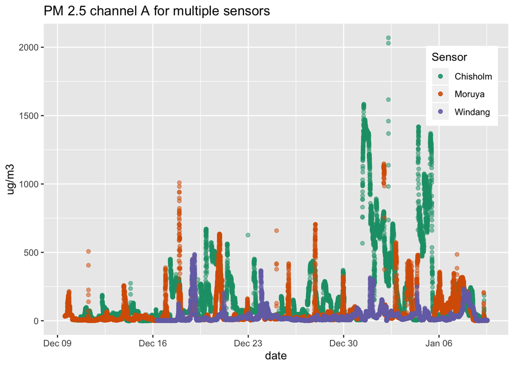

```r
colors <- c("Chisholm" = "#1b9e77",
            "Moruya" = "#d95f02",
            "Windang" = "#7570b3")

gg <- ggplot(data = pat_chisholm$data) +
  geom_point(aes(x = pat_chisholm$data$datetime,
                 y = pat_chisholm$data$pm25_A,
                 color = "Chisholm"), alpha = 0.5) +
  geom_point(data = pat_moruya$data,
             aes(x = pat_moruya$data$datetime,
                 y = pat_moruya$data$pm25_A,
                 color = "Moruya"), alpha = 0.5) +
  geom_point(data = pat_windang$data,
             aes(x = pat_windang$data$datetime,
                 y = pat_windang$data$pm25_A,
                 color = "Windang"), alpha = 0.5) +
  labs(title = "PM 2.5 channel A for multiple sensors" ) +
  xlab("date") +
  ylab("ug/m3") +
  scale_colour_manual(name="Sensor",values=colors) +
  theme(legend.position= c(0.9, 0.8))

gg
```

The PurpleAir website states that the sensors can reliably detect PM 2.5 values up to 1000 μg/m³. In this case we are seeing two relatively new sensors called “Chisholm ACT Australia” and “MORUYA HEADS”, where channel A is reporting out of spec data.

### Download data based on proximity

Let’s see if there are other sensors that are closer in proximity that are also reporting out of spec. This chunk of code checks to see if the ‘pat’ objects are downloaded locally, if not it will download them.

```r
filePath_bungendore <- file.path(archiveBaseDir, "pat_bungendore.rda")
if ( file.exists(filePath_bungendore) ) {
  pat_bungendore <- get(load(filePath_bungendore))
}

filePath_downer <- file.path(archiveBaseDir, "pat_downer.rda")
if ( file.exists(filePath_downer) ) {
  pat_downer <- get(load(filePath_downer))
} else {
  pat_bungendore <- pat_createNew(label = "Bungendore, NSW Australia",
                                  pas = pas_au,
                                  startdate = 20191229,
                                  enddate = 20200110)
  save(pat_bungendore, file = filePath_bungendore)

  pat_downer <- pat_createNew(label = "Downer",
                              pas = pas_au,
                              startdate = 20191220,
                              enddate = 20200110)
  save(pat_downer, file = filePath_downer)
}
```

These sensors have a shorter data history but are more closely located and should have more correlated signal. This chunk uses ggplot to plot A channel again from “Chisholm ACT Australia” sensor in the same green color as the plot above in addition to the channel A data from the two closest sensors nearby.

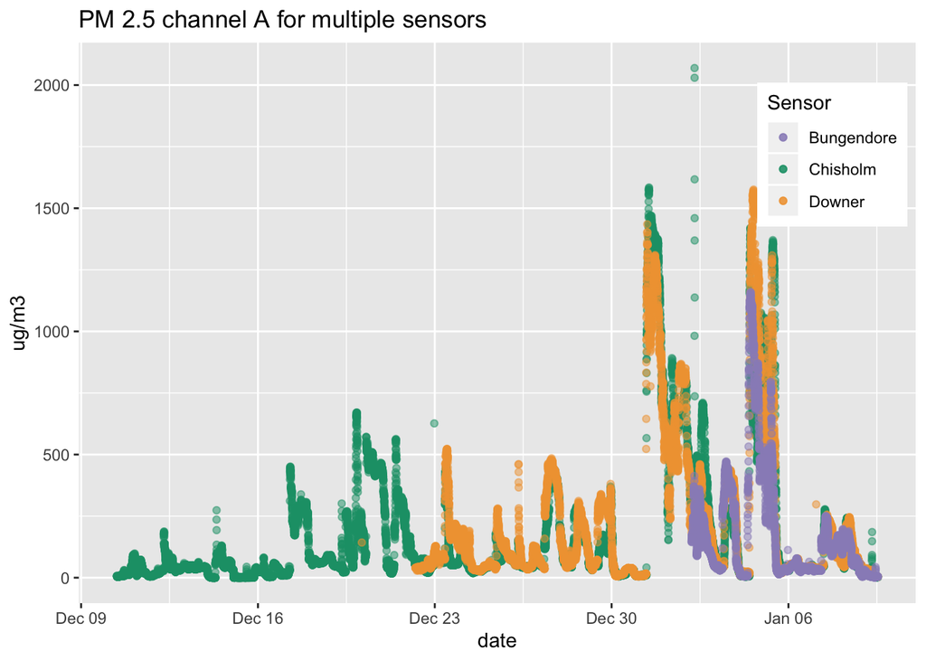

```r
colors <- c("Chisholm" = "#1b9e77",
            "Downer" = "#f1a340",
            "Bungendore" = "#998ec3")

gg <- ggplot(data = pat_chisholm$data) +
  geom_point(aes(x = pat_chisholm$data$datetime,
                 y = pat_chisholm$data$pm25_A,
                 color = "Chisholm"), alpha = 0.5) +
  geom_point(data = pat_downer$data,
             aes(x = pat_downer$data$datetime,
                 y = pat_downer$data$pm25_A,
                 color = "Downer"), alpha = 0.5) +
  geom_point(data = pat_bungendore$data,
             aes(x = pat_bungendore$data$datetime,
                 y = pat_bungendore$data$pm25_A,
                 color = "Bungendore"), alpha = 0.5) +
  labs(title = "PM 2.5 channel A for multiple sensors" ) +
  xlab("date") +
  ylab("ug/m3") +
  scale_colour_manual(name="Sensor",values=colors) +
  theme(legend.position= c(0.9, 0.8))

gg
```

It appears that all three sensors are reporting out of spec values on the same days between December 30, 2019 and January 6, 2020. We can check on the state of health of the sensors as another way to help validate the findings.

### Sensor state of health

After looking at sensor data from numerous sensors over long periods of time, we have noticed that the ‘pat’ data quality does degrade at times. A quick way to quantify data quality is to simply calculate the r<sup>2</sup> value between channels A and B. Based on the r<sup>2</sup> value, which we equate to the state of health index, the daily data quality is categorized as good, fair, or poor. Typically, new sensors have not had time for outside factors to degrade data quality, but for a quick sanity check, we can use the `pat_dailySoHIndexPlot` function to plot the daily state of health index. This function plots both channels A and B with a daily indicator along the bottom which indicates the sensor health.

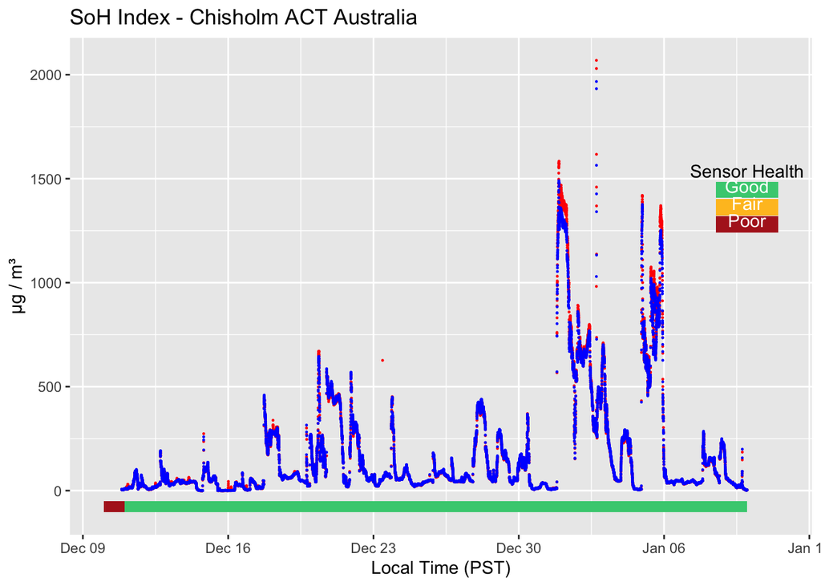

```r
pat_dailySoHIndexPlot(pat_chisholm)
```

Both channels are reporting good health so we don’t really know what to make of these correlated, out of spec values. Perhaps the smoke is so bad that the sensors are malfunctioning and reporting inaccurate values or maybe these sensors are failing simultaneously by chance. Either way, three new, co-located sensors reporting out of spec values on the same days is an interesting finding nonetheless.

## Working with ‘airsensor’ data

Another way to look at the PurpleAir sensor data is to convert the ‘pat’ into an ‘airsensor’ object. This chunk aggregates data from a pat object into an ‘airsensor’ object that has appropriate metadata to be used with the *PWFSLSmoke* package.

```r
airsensor_chisholm <- pat_createAirSensor(
  pat = pat_chisholm,
  period = "1 hour",
  parameter = "pm25",
  channel = "a",
  qc_algorithm = "hourly_AB_01",
  min_count = 20,
  aggregation_FUN = pat_aggregate
)
```

### Advanced plotting with **AirMonitorPlots**

Now that the data are classified as an airsensor object, we can use a variety of other plotting functions located in the *PWFSLSmoke* package to explore more.

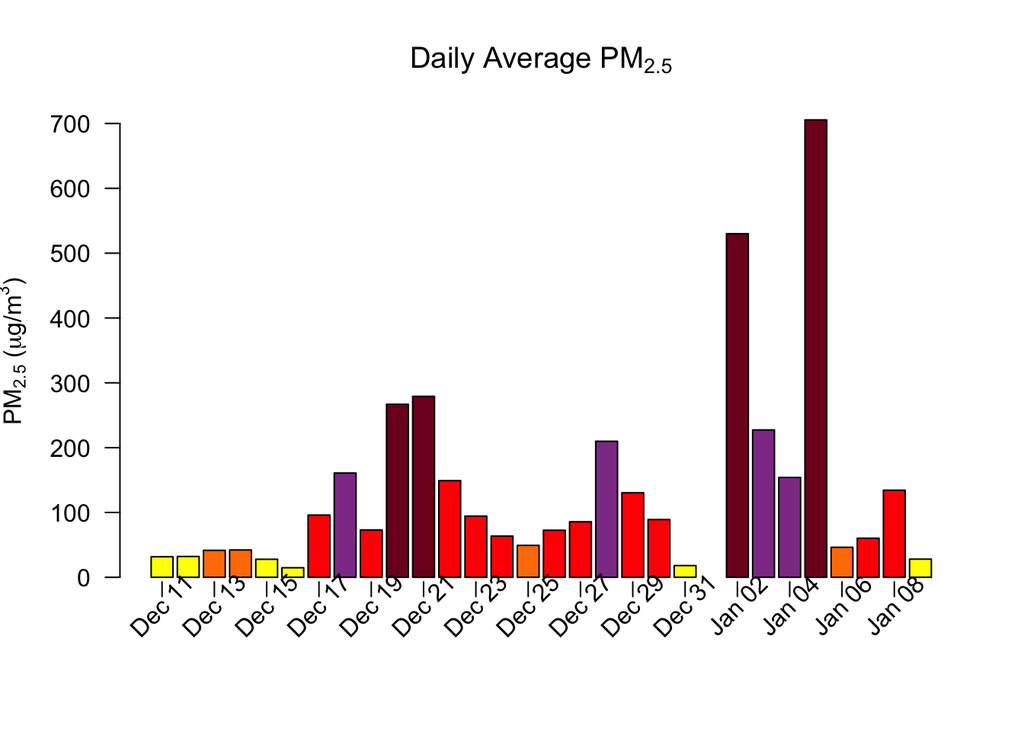

```r
PWFSLSmoke::monitor_dailyBarplot(airsensor_chisholm)
```

Here, the bar associated with each day is colored by the AQI. In this time period there were only 10 days that the daily average AQI fell below “Unhealthy”.

### Incorporating wind data

Lastly, we can use the ‘airsensor’ object to explore where the smoke in the area came from. This chunk finds the nearest meteorological site, and plots it on the map in blue along with the Canberra sensors.

```r
canberra_labels <- c("Chisholm ACT Australia",
                     "Bungendore, NSW Australia",
                     "Downer")

pas_canberra <-
  pas_au%>%
  pas_filterNear(latitude = pat_chisholm$meta$latitude,
                 longitude = pat_chisholm$meta$longitude,
                 radius = "40 km")

lon <- pat_chisholm$meta$longitude
lat <- pat_chisholm$meta$latitude

closestSite <- worldmet::getMeta(lon = lon,
                                 lat = lat,
                                 n = 1,
                                 plot = FALSE)[1,]

m <- pas_leaflet(pas_canberra)

leaf <- m %>%
  leaflet::addCircleMarkers(lng = closestSite$longitude,
                            lat = closestSite$latitude)
leaf
```

[interactive chart not shown]

The `sensor_pollutionRose` function takes an ‘airsensor’ object, finds hourly wind direction and speed data from the nearest meterological site, and plots a traditional wind rose plot for wind direction and PM2.5. In this case, it looks like the smoke is coming mostly from the E/NE which is validated by this wind rose plot from the Australian Bureau of Meteorology here: http://www.bom.gov.au/cgi-bin/climate/cgi_bin_scripts/windrose_selector.cgi?period=Dec&type=9&location=72150

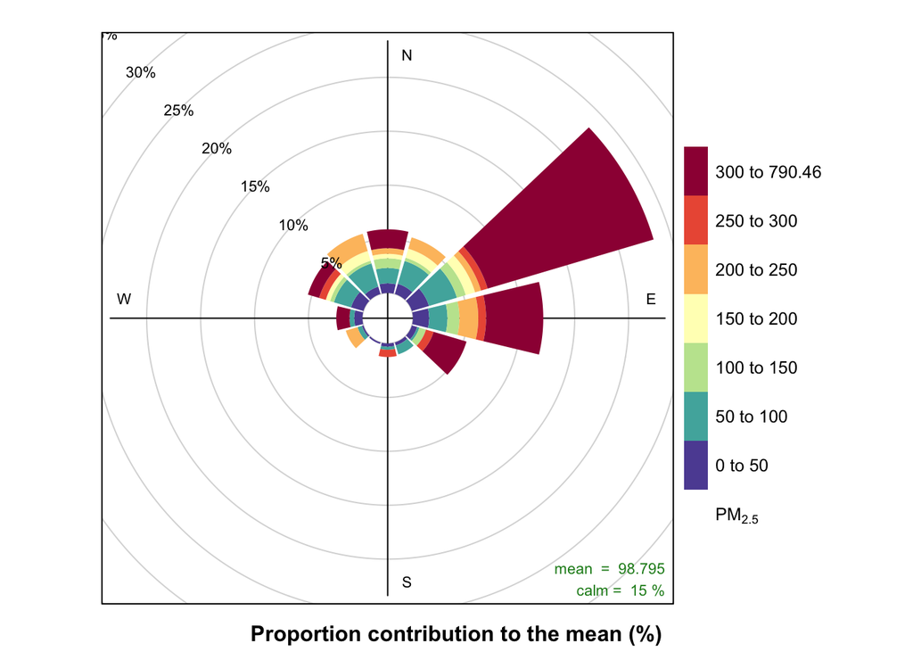

```r
sensor_pollutionRose(sensor = airsensor_chisholm,
                     windData = NULL,
                     statistic = "prop.mean")
```

*Happy Exploring!*

*Mazama Science*